# Data Challenge - Resume Analyzer

Anna Kadurina

## 👋 Introduction

This project focuses on developing a Resume Analyzer – an intelligent tool that leverages natural language processing (NLP) to analyze resumes, extract structured information, and provide feedback using deep learning models. The long-term vision is to create a career assistant that helps job seekers craft effective resumes by simulating how AI-driven Applicant Tracking Systems (ATS) might evaluate them. This notebook represents the first phase of the development: preparing the data and training a model for Named Entity Recognition (NER) and resume scoring.

## 📚 Table of Contents

1. **🌍 Domain Understanding**
2. **📦 Data Provisioning**
   - Data Requirements
   - Data Collection
   - Ethical Considerations
   - Data Understanding
   - Data Preparation
3. **🔮 Predictions**
   - BERT
   - RoBERTa
   - Comparison
4. **📈 Resume Scoring Engine**
5. **🚀 Conclusion**

## 1. 🌍 Domain Understanding

In today’s competitive job market, resumes play a critical role in making a strong first impression. Many organizations use automated systems to screen resumes, and poor formatting, lack of keywords, or missing sections often result in qualified candidates being filtered out prematurely.

This project addresses that issue by using AI to replicate the resume evaluation process. The system will identify key information such as skills, education, and job experience from unstructured text and provide suggestions for improvement. The immediate goal is to train a model capable of extracting relevant resume entities and scoring them using rule-based logic.

## 2. 📦 Data Provisioning

### Data Requirements

#### Data Elements

##### Resume Content

- **Data Type:** Free-form Text
- **Example:** Full resume content including education, skills, and work experience.
- **Purpose:** Source for Named Entity Recognition (NER) and scoring.
- **Content:** Unstructured, semi-formatted text.

##### Named Entities (NER Output)

- **Data Type:** Token Spans with Labels
- **Example:**
  - `Python` → Skill
  - `Harvard University` → College Name
  - `Software Engineer` → Designation
- **Purpose:** Structured extraction from resume text.
- **Format:** BIO-tagging (Begin, Inside, Outside)

##### Resume Category (Optional)

- **Data Type:** Category Label
- **Example:** `Data Science`, `HR`, `Web Developer`
- **Purpose:** Used for testing generalizability or future classification
- **Source:** Gaurav Dutta Dataset

##### 💬 Synthetic Data (Generated with ChatGPT)

##### Artificially Created Resumes

- **Data Type:** Textual (same structure as real resumes)
- **Example:** A ChatGPT-generated resume for a Marketing Manager with 10 years of experience
- **Purpose:** Supplement real data to increase diversity across roles, styles, and backgrounds

#### Data Volume

To train robust NLP models, a significant amount of labeled and unlabeled text data is needed. For this project:

- A minimum of 1000 labeled resumes is preferred for effective NER training.
- Unlabeled resumes will support testing and rule-based scoring logic.
- Synthetic resumes generated using ChatGPT will supplement the datasets to increase diversity and realism.

#### Data Variety

The model should generalize well across industries and job roles. Therefore, the data must include:

- Resumes from various domains: tech, HR, education, healthcare, etc.
- Different writing styles: concise bullet points, paragraph-style narratives.
- Varying levels of experience: entry-level to executive.

#### Data Quality Standards

High-quality training data must be:

- **Correctly annotated**: Entities like skills and education must be accurately labeled.
- **Consistent**: Annotation format must follow BIO tagging conventions.
- **Readable and clean**: No corrupted or unreadable files.

#### Data Dictionary

| **Entity Name** | **Description** | **Example** |
| --- | --- | --- |
| `Name` | The candidate’s full name (if included, anonymized for training) | “Anna Kadurina” |
| `Email` | Contact email (removed or anonymized) | “example@email.com” |
| `Phone Number` | Candidate’s contact number (removed or anonymized) | “+31 6 12345678” |
| `Location` | City or country the candidate mentions | “Amsterdam, Netherlands” |
| `Years of Experience` | Total or job-specific experience | “5 years of experience” |
| `Skills` | Technical or soft skills | “Python”, “Teamwork” |
| `Degree` | Academic qualifications | “Bachelor of Science” |
| `College Name` | Institution where degree was earned | “Fontys University” |
| `Education` | Broader education references | “Completed MBA in 2022” |
| `Companies Worked At` | Past employers | “Google”, “ING” |
| `Designation` | Job titles held | “Backend Developer” |
| `Projects` | Specific projects mentioned | “Inventory App for Clients” |
| `Certifications` | Additional formal certifications | “AWS Certified Solutions Architect” |
| `Languages` | Language proficiencies | “English, Dutch” |
| `Tools/Technologies` | Software tools and platforms | “Git”, “Azure”, “Figma” |
| `Summary/Objectives` | Introductory paragraph on goals or experience | “Motivated software engineer...” |
| `Achievements` | Noteworthy accomplishments | “Dean’s List 2021” |

### 🗂️ Data Collection

#### Data Sources

**Primary Datasets:**

- **DataTurks Resume NER**: JSON-based dataset with annotated resume entities.
- **Gaurav Dutta Resume Dataset**: A collection of text-based resumes categorized by job roles.

**Supplementary Data:**

- **Synthetic Resumes**: Created using ChatGPT prompts tailored for industry, seniority level, and writing style diversity. These will fill gaps in underrepresented domains and enhance model robustness.

#### Collecting the data

- The datasets will be downloaded from **Kaggle** and stored locally in raw format.
- Synthetic data will be generated using guided prompts and stored alongside the real datasets.
- A preprocessing pipeline will convert the datasets into a format compatible with Hugging Face Transformers, using BIO-tagging for labeled text.

### ⚖️ Ethical Considerations

As this project involves analyzing resume content—potentially containing sensitive personal data—ethical awareness is essential throughout the data lifecycle. Below are the key ethical dimensions and how they are addressed in this project.

#### 1. Data Privacy

Resumes frequently include **personally identifiable information (PII)** such as names, emails, phone numbers, addresses, and employer names. Exposure or misuse of such data could compromise user privacy.

**Mitigation Measures:**

- **Anonymization**: All PII will be removed or obfuscated before using any data for training or evaluation.
- **No Storage of User Data**: During prototype testing, any resumes submitted by users will be processed temporarily and never stored.
- **Local Processing**: Data remains in a local environment; no resumes are uploaded to public clouds or external APIs.

#### 2. Bias and Fairness

AI models trained on biased datasets can amplify societal inequities, especially in hiring. For example, they may favor certain degrees, schools, or professional titles based on historical data.

**Mitigation Measures:**

- **Synthetic Diversity**: Artificial resumes created with ChatGPT will include varied names, backgrounds, job roles, and education types.
- **Bias Testing**: The model will be tested on resumes representing diverse genders, regions, and industries to observe output consistency.
- **Score Explanation**: Scoring logic will be transparent and rules-based to avoid learned bias in feedback.

#### 3. Transparency and Explainability

Users must understand why they received a certain score or suggestion.

**Practices for Transparency:**

- All feedback is based on **clearly extractable entities** (e.g., missing skills, lack of education info).
- The system avoids black-box scoring. For example:  
  *"Your resume is missing a skills section"* is more helpful than *"Score: 4"*.

#### 4. Misuse Prevention

An AI-based resume evaluator could be misused to unfairly filter candidates in automated hiring tools.

**Boundaries of Use:**

- This tool is designed for **self-assessment and guidance**, not as a gatekeeping mechanism.
- Clear disclaimers will inform users that the feedback is meant to assist—not replace—human judgment or professional resume reviews.

### Imports of libraries

```python
import json
import pandas as pd
import matplotlib.pyplot as plt
import seaborn as sns
import numpy as np
import re
from collections import Counter, defaultdict
from wordcloud import WordCloud
import nltk
from nltk.corpus import stopwords
from transformers import AutoTokenizer, AutoModelForTokenClassification, TrainingArguments, Trainer, DataCollatorForTokenClassification
from datasets import Dataset
from seqeval.metrics import classification_report
from sklearn.metrics import confusion_matrix, ConfusionMatrixDisplay
import openai
```

[output not shown]

### Data Loading and Sampling

In this section, we load the `resumes.json` file and take initial samples to understand the structure, entity annotations, and text quality. This helps verify if the data meets our expectations for NER training.

The dataset is in JSON Lines format, where each line is a separate JSON object containing a piece of resume text and annotated entities.

```python
with open("data/resumes.json", "r", encoding="utf-8") as f:
    lines = f.readlines()

data = [json.loads(line) for line in lines]

df = pd.DataFrame(data)
print(f"Total samples loaded: {len(df)}")
df.head(2)
```

```
Total samples loaded: 220
```

|  | content | annotation | extras |
| --- | --- | --- | --- |
| 0 | Abhishek Jha\nApplication Development Associat... | [{'label': ['Skills'], 'points': [{'start': 12... | None |
| 1 | Afreen Jamadar\nActive member of IIIT Committe... | [{'label': ['Email Address'], 'points': [{'sta... | None |

### 📊 Data Understanding

In this section, we analyze the structure, quality, and statistical properties of the DataTurks Resume NER dataset. This deep understanding ensures our data is reliable for fine-tuning a Named Entity Recognition (NER) model.

As we saw already, the dataset is stored in JSON lines format, where each record contains:

- `content`: Full resume text
- `annotation`: A list of entities, each with:
  - `label`: Entity type (e.g., "Skills")
  - `points`: Span with `start`, `end`, and `text`

Some of the resume labels don’t line up with the text, so we automatically search for them in the resume and fix their position. If found, we keep them. If not, we just note that the model couldn’t find them. To be able to do proper Data Understanding, we are going to to fix these potentially broken span annotations by finding the actual position (start, end) of each labeled entity (text) within the resume content. If the position is found using a regex match, the annotation is marked as fixed=True. Otherwise, it is flagged as unfixed for potential review.

```python
def clean_and_fix_annotations(row):
    content = row["content"]
    fixed = []

    for ann in row["annotation"]:
        if not isinstance(ann.get("label"), list) or not ann.get("label"):
            continue
        if not isinstance(ann.get("points"), list) or not ann.get("points"):
            continue

        label = ann["label"][0]
        point = ann["points"][0]
        entity_text = point.get("text", "").strip()

        if not entity_text:
            continue

        matches = [m for m in re.finditer(re.escape(entity_text), content)]
        if matches:
            match = matches[0]
            fixed.append({
                "label": label,
                "text": entity_text,
                "start": match.start(),
                "end": match.end(),
                "fixed": True
            })
        else:
            fixed.append({
                "label": label,
                "text": entity_text,
                "start": None,
                "end": None,
                "fixed": False
            })

    return fixed

df["clean_annotations"] = df.apply(clean_and_fix_annotations, axis=1)

total_entities = sum(len(anns) for anns in df["clean_annotations"])
fixed_entities = sum(1 for anns in df["clean_annotations"] for ann in anns if ann["fixed"])
```

```python
sample = df.iloc[0]

print(sample["content"][:500])

print("\n🔍 Fixed Annotations:\n")
for ann in sample["clean_annotations"]:
    label = ann["label"]
    text = ann["text"]
    start = ann["start"]
    end = ann["end"]
    fixed = ann["fixed"]

    if fixed and start is not None and end is not None:
        extracted = sample["content"][start:end]
        print(f"- {label}: '{text}' | Span: ({start}, {end}) | Extracted: '{extracted}'")
    else:
        print(f"- {label}: '{text}' | Not found")
```

```
Abhishek Jha
Application Development Associate - Accenture

Bengaluru, Karnataka - Email me on Indeed: indeed.com/r/Abhishek-Jha/10e7a8cb732bc43a

• To work for an organization which provides me the opportunity to improve my skills
and knowledge for my individual and company's growth in best possible ways.

Willing to relocate to: Bangalore, Karnataka

WORK EXPERIENCE

Application Development Associate

Accenture -

November 2017 to Present

Role: Currently working on Chat-bot. Developing Backen

🔍 Fixed Annotations:

- Skills: '• Programming language: C, C++, Java
• Oracle PeopleSoft
• Internet Of Things
• Machine Learning
• Database Management System
• Computer Networks
• Operating System worked on: Linux, Windows, Mac

Non - Technical Skills

• Honest and Hard-Working
• Tolerant and Flexible to Different Situations
• Polite and Calm
• Team-Player' | Span: (1296, 1622) | Extracted: '• Programming language: C, C++, Java
• Oracle PeopleSoft
• Internet Of Things
• Machine Learning
• Database Management System
```

[output cut: 9 more lines]

```
- Skills: 'C (Less than 1 year), Database (Less than 1 year), Database Management (Less than 1 year),
Database Management System (Less than 1 year), Java (Less than 1 year)' | Span: (993, 1154) | Extracted: 'C (Less than 1 year), Database (Less than 1 year), Database Management (Less than 1 year),
Database Management System (Less than 1 year), Java (Less than 1 year)'
- College Name: 'Kendriya Vidyalaya' | Span: (939, 957) | Extracted: 'Kendriya Vidyalaya'
- College Name: 'Woodbine modern school' | Span: (883, 905) | Extracted: 'Woodbine modern school'
- Graduation Year: '2017' | Span: (429, 433) | Extracted: '2017'
- College Name: 'B.v.b college of engineering and technology' | Span: (771, 814) | Extracted: 'B.v.b college of engineering and technology'
- Designation: 'B.E in Information science and engineering' | Span: (727, 769) | Extracted: 'B.E in Information science and engineering'
- Companies worked at: 'Accenture' | Span: (49, 58) | Extracted: 'Accenture'
- Designation: 'Application Development Associate' | Span: (13, 46) | Extracted: 'Application Development Associate'
- Email Address: 'Indeed: indeed.com/r/Abhishek-Jha/10e7a8cb732bc43a' | Span: (95, 145) | Extracted: 'Indeed: indeed.com/r/Abhishek-Jha/10e7a8cb732bc43a'
- Location: 'Bengaluru' | Span: (60, 69) | Extracted: 'Bengaluru'
- Companies worked at: 'Accenture' | Span: (49, 58) | Extracted: 'Accenture'
- Designation: 'Application Development Associate' | Span: (13, 46) | Extracted: 'Application Development Associate'
- Name: 'Abhishek Jha' | Span: (0, 12) | Extracted: 'Abhishek Jha'
```

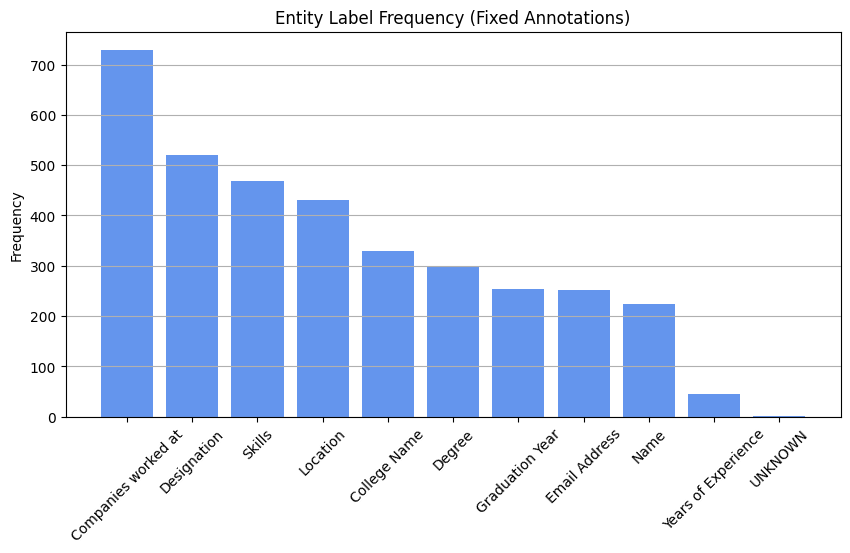

|  | Entity | Count |
| --- | --- | --- |
| 4 | Companies worked at | 729 |
| 3 | Designation | 521 |
| 0 | Skills | 468 |
| 6 | Location | 430 |
| 1 | College Name | 330 |
| 8 | Degree | 298 |
| 2 | Graduation Year | 254 |
| 5 | Email Address | 252 |
| 7 | Name | 224 |
| 9 | Years of Experience | 44 |
| 10 | UNKNOWN | 2 |

```python
label_counts = Counter()
for anns in df["clean_annotations"]:
    for ann in anns:
        if ann["fixed"]:
            label_counts[ann["label"]] += 1

label_df = pd.DataFrame(label_counts.items(), columns=["Entity", "Count"]).sort_values("Count", ascending=False)

plt.figure(figsize=(10, 5))
plt.bar(label_df["Entity"], label_df["Count"], color="cornflowerblue")
plt.xticks(rotation=45)
plt.ylabel("Frequency")
plt.title("Entity Label Frequency (Fixed Annotations)")
plt.grid(axis="y")
plt.show()

label_df
```

Next, I checked how long resumes are. The histogram below shows the character length of resumes in the dataset. Most resumes range between 1,000 and 5,000 characters, with a few outliers exceeding 10,000. The average length is informative for setting token limits during model training and truncation.

```
Resume Length (Characters):
- Mean: 3697.14
- Min: 346
- Max: 20143
- Std: 3275.18
```

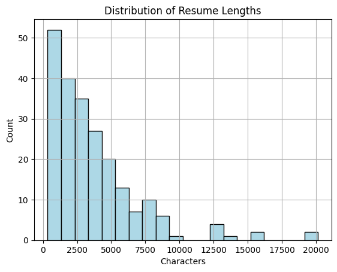

```python
df["char_length"] = df["content"].apply(len)

print("Resume Length (Characters):")
print(f"- Mean: {df['char_length'].mean():.2f}")
print(f"- Min: {df['char_length'].min()}")
print(f"- Max: {df['char_length'].max()}")
print(f"- Std: {df['char_length'].std():.2f}")

plt.hist(df["char_length"], bins=20, color="lightblue", edgecolor="black")
plt.title("Distribution of Resume Lengths")
plt.xlabel("Characters")
plt.ylabel("Count")
plt.grid(True)
plt.show()
```

Now, we counted how many labeled sections (like skills or education) each resume has. Most resumes have around 10-20, which is enough for the model to learn from.

```
Entities Per Resume:
- Mean: 16.15
- Min: 5
- Max: 82
```

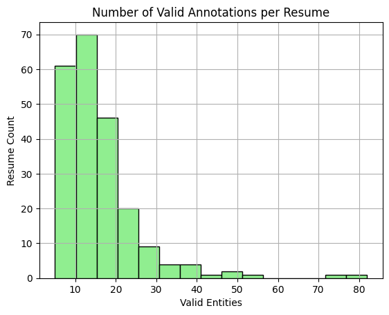

```python
df["num_fixed_entities"] = df["clean_annotations"].apply(lambda x: sum(1 for ann in x if ann["fixed"]))

print("Entities Per Resume:")
print(f"- Mean: {df['num_fixed_entities'].mean():.2f}")
print(f"- Min: {df['num_fixed_entities'].min()}")
print(f"- Max: {df['num_fixed_entities'].max()}")

plt.hist(df["num_fixed_entities"], bins=15, color="lightgreen", edgecolor="black")
plt.title("Number of Valid Annotations per Resume")
plt.xlabel("Valid Entities")
plt.ylabel("Resume Count")
plt.grid(True)
plt.show()
```

In the next snippet, we check a few random labeled examples to see if labels match the actual resume content - and they do, like degrees and company names. It helps confirm that the annotation repair process worked as intended by showing correctly matched labels and their corresponding spans.

```python
examples = []
for anns in df["clean_annotations"]:
    for ann in anns:
        if ann["fixed"]:
            examples.append((ann["label"], ann["text"]))

import random
random.shuffle(examples)
sample_df = pd.DataFrame(examples[:10], columns=["Label", "Text"])
sample_df
```

|  | Label | Text |
| --- | --- | --- |
| 0 | Designation | Senior Software Analyst |
| 1 | Email Address | indeed.com/r/Ramakrishna-\nRao/0b57f5f9d35b9e5c |
| 2 | Degree | Bachelor of Engineering in Electronics and Com... |
| 3 | Companies worked at | Sap labs |
| 4 | Location | Telangana |
| 5 | Degree | B.SC. |
| 6 | Designation | Global Production Support Lead, |
| 7 | Location | Bangalore |
| 8 | Companies worked at | Infosys Limited |
| 9 | Degree | BSc |

Now, we check for duplicate resumes and we can see there is 1 duplicate.

```python
duplicate_count = df.duplicated(subset=["content"]).sum()
print(f"🔁 Exact duplicate resumes: {duplicate_count}")
```

```
🔁 Exact duplicate resumes: 1
```

Next, we see the the top 20 most frequent non-stopword tokens found across all resumes. This gives insight into common vocabulary, which helps in understanding domain relevance and guiding model training or token filtering decisions. Words like "management", "project", and "skills" appear a lot, showing what people focus on when describing their experience.

```python
nltk.download('stopwords')

stop_words = set(stopwords.words("english"))

def tokenize(text):
    tokens = re.findall(r'\b\w+\b', text.lower())
    return [word for word in tokens if word not in stop_words]

df["tokens"] = df["content"].apply(tokenize)
all_tokens = [token for tokens in df["tokens"] for token in tokens]
token_counts = Counter(all_tokens)

pd.DataFrame(token_counts.most_common(20), columns=["Word", "Frequency"])
```

|  | Word | Frequency |
| --- | --- | --- |
| 0 | indeed | 741 |
| 1 | management | 671 |
| 2 | com | 627 |
| 3 | download | 609 |
| 4 | experience | 589 |
| 5 | r | 569 |
| 6 | project | 543 |
| 7 | team | 529 |
| 8 | skills | 500 |
| 9 | testing | 473 |
| 10 | work | 458 |
| 11 | 1 | 456 |
| 12 | data | 453 |
| 13 | microsoft | 449 |
| 14 | test | 420 |
| 15 | using | 416 |
| 16 | years | 386 |
| 17 | client | 363 |
| 18 | https | 354 |
| 19 | year | 353 |

The next histogram shows the length (in characters) of the extracted entity values. Most entities are under 100 characters, indicating concise labeling (e.g., job titles or skills). A few outliers may contain longer segments, such as full education or address fields, which could require special handling during tokenization.

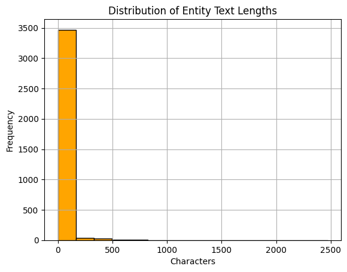

```python
entity_lengths = []

for annotations in df["clean_annotations"]:
    for ann in annotations:
        if ann["fixed"]:
            entity_lengths.append(len(ann["text"]))

plt.hist(entity_lengths, bins=15, color="orange", edgecolor="black")
plt.title("Distribution of Entity Text Lengths")
plt.xlabel("Characters")
plt.ylabel("Frequency")
plt.grid(True)
plt.show()
```

This table shows cases where the same text was labeled with multiple entity types across different resumes. For instance, "microsoft" was tagged as both a company and a designation. These ambiguities can introduce noise into the model and may require disambiguation or context-aware handling.

```python
text_to_labels = defaultdict(set)

for anns in df["clean_annotations"]:
    for ann in anns:
        if ann["fixed"]:
            text_to_labels[ann["text"].lower()].add(ann["label"])

ambiguous = {text: labels for text, labels in text_to_labels.items() if len(labels) > 1}
pd.DataFrame([(k, list(v)) for k, v in ambiguous.items()], columns=["Text", "Labels"]).head(10)
```

|  | Text | Labels |
| --- | --- | --- |
| 0 | 2012 | [UNKNOWN, Graduation Year] |
| 1 | 2011 | [Degree, College Name, Graduation Year] |
| 2 | oracle | [Skills, Companies worked at] |
| 3 | microsoft | [Companies worked at, Designation] |
| 4 | sap abap | [Skills, Companies worked at] |
| 5 | 2004 | [Years of Experience, Graduation Year] |
| 6 | sap | [Skills, Companies worked at] |
| 7 | pune university | [Companies worked at, College Name] |
| 8 | android | [Degree, Skills] |
| 9 | 2001 | [Graduation Year, Designation] |

Now, we check if the resumes contain weird symbols or foreigner characters. None of the resumes exceeded the 5% threshold, confirming that the dataset is clean and fully compatible with standard tokenizers.

```python
df["non_ascii_ratio"] = df["content"].apply(lambda x: sum(ord(c) > 127 for c in x) / len(x))
print("Resumes with >5% non-ASCII characters:", (df["non_ascii_ratio"] > 0.05).sum())
```

```
Resumes with >5% non-ASCII characters: 0
```

On the word cloud we see the most frequent words across all resume texts. Larger words appear more often. It offers a quick glance at the dominant themes in the dataset, such as common technologies, roles, or keywords used by applicants.

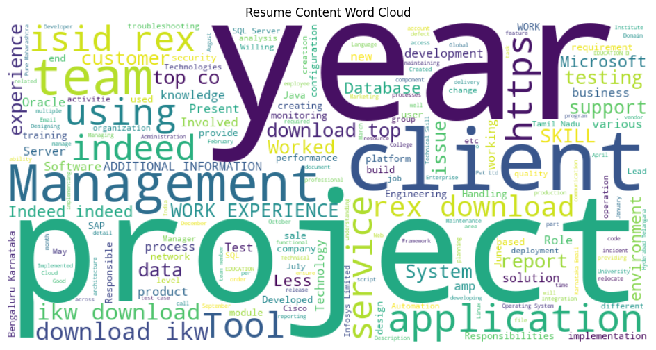

```python
all_text = " ".join(df["content"].tolist())

wordcloud = WordCloud(width=800, height=400, background_color="white").generate(all_text)

plt.figure(figsize=(15, 6))
plt.imshow(wordcloud, interpolation='bilinear')
plt.axis("off")
plt.title("Resume Content Word Cloud")
plt.show()
```

The scatter plot shows the relationship between resume length (in characters) and the number of extracted entities. While there is a slight upward trend — longer resumes tend to contain more labeled entities — the correlation is not strict, as some short resumes are rich in labeled data.

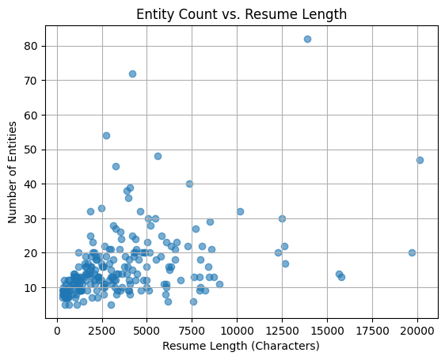

```python
plt.scatter(df["char_length"], df["num_fixed_entities"], alpha=0.6)
plt.xlabel("Resume Length (Characters)")
plt.ylabel("Number of Entities")
plt.title("Entity Count vs. Resume Length")
plt.grid(True)
plt.show()
```

### 🛠️ Data Preparation

In this section, we transform the cleaned dataset into a format suitable for fine-tuning a transformer-based Named Entity Recognition (NER) model. This involves converting annotated text spans into token-level BIO labels, tokenizing the resume text using a Hugging Face tokenizer, and optionally enriching the dataset with synthetic examples.

#### 1. Synthetic Resume Generation

To improve the diversity and generalizability of the model, we enrich the training data with synthetic resumes. These are generated using ChatGPT prompts and are meant to fill gaps in underrepresented industries or experience levels.

#### Why Synthetic Data?

- Boosts data volume for low-frequency entities
- Adds domain variation (e.g., art, medicine, blue-collar jobs)
- Reduces overfitting on a small dataset

```python
import time
from pathlib import Path
from openai import OpenAI

client = OpenAI(api_key="secret")
```

In the next code cells, we generate a large synthetic dataset of resumes using OpenAI's GPT-3.5 model. We define a list of 80 job titles and create a prompt template that requests a realistic, ATS-friendly resume for each role. For each job title, we generate 10 unique resumes by querying the OpenAI API, storing the output text along with an empty clean_annotations field (which will be used later for entity labeling). These resumes are saved to a local JSON file for reuse. After generation, we load the synthetic resumes into a DataFrame and merge them with our original annotated dataset, resulting in a combined dataset of over 1000 resumes. This expanded dataset will support better model training by increasing label diversity and helping the model generalize across job roles.

```python
additional_job_titles = [
    "Project Manager", "Business Analyst", "Content Writer", "Product Manager", "Electrical Engineer",
    "Operations Coordinator", "Social Media Manager", "Legal Assistant", "QA Tester", "Data Engineer",

    "Financial Analyst", "Research Assistant", "Recruiter", "Technical Support Specialist", "DevOps Engineer",
    "Pharmacist", "Mechanical Engineer", "Interior Designer", "IT Consultant", "Event Planner",

    "Web Developer", "Lab Technician", "Translator", "Chemist", "Video Editor",
    "Accountant", "IT Support Specialist", "Real Estate Agent", "Architect", "Digital Marketer",

    "Nurse Practitioner", "Front-End Developer", "Back-End Developer", "Data Scientist", "Economist",
    "Paralegal", "Teacher", "Administrative Assistant", "AI Researcher", "Personal Trainer",

    "Mobile App Developer", "Supply Chain Analyst", "Customer Success Manager", "Policy Advisor", "Systems Analyst",
    "Network Administrator", "Community Manager", "Executive Assistant", "Journalist", "Environmental Engineer",

    "Cybersecurity Analyst", "Biologist", "Speech Therapist", "Radiologic Technologist", "Auditor",
    "Content Strategist", "Marketing Analyst", "E-commerce Specialist", "Database Administrator", "Loan Officer",

    "Bartender", "Sales Manager", "Animator", "Voice Actor", "Photographer",
    "Nutritionist", "SEO Specialist", "Copywriter", "Software Tester", "Biomedical Engineer"
]
```

```python
job_titles = [
    "Software Engineer", "Marketing Manager", "UX Designer", "Data Analyst",
    "HR Specialist", "Sales Associate", "Civil Engineer", "Medical Assistant",
    "Graphic Designer", "Customer Support Agent"
] + additional_job_titles
```

```python
def generate_resume_prompt(job_title):
    return f"""Write a detailed and realistic resume for a person applying for the role of a {job_title}.
Include the following sections in plain text (no formatting):
- Name
- Email address
- Phone number
- Location
- Summary
- Skills
- Education
- Work experience (with job title, company, and responsibilities)

Make it natural and ATS-friendly. Output as a single block of text.
"""
```

```python
synthetic_resumes = []
save_path = "data/synthetic_resumes.json"

for title in job_titles:
    for i in range(10):
        prompt = generate_resume_prompt(title)
        try:
            response = client.chat.completions.create(
                model="gpt-3.5-turbo",
                messages=[
                    {"role": "system", "content": "You are a helpful resume writer."},
                    {"role": "user", "content": prompt}
                ],
                temperature=0.7,
                max_tokens=700
            )

            resume_text = response.choices[0].message.content.strip()

            synthetic_resumes.append({
                "content": resume_text,
                "clean_annotations": []
            })

            print(f"✅ Generated resume {i+1} for: {title}")
            time.sleep(1.5)

        except Exception as e:
            print(f"⚠️ Failed for {title} #{i+1}: {e}")
            time.sleep(5)

Path("data").mkdir(exist_ok=True)
with open(save_path, "w", encoding="utf-8") as f:
    json.dump(synthetic_resumes, f, indent=2)

print(f"\n🎉 Saved {len(synthetic_resumes)} synthetic resumes to {save_path}")
```

```python
with open("data/synthetic_resumes.json", "r", encoding="utf-8") as f:
    synthetic_data = json.load(f)

df_synthetic = pd.DataFrame(synthetic_data)
print(f"Synthetic dataset size: {len(df_synthetic)}")
print(f"Original dataset size: {len(df)}")

df_combined = pd.concat([df, df_synthetic], ignore_index=True)
print(f"Combined dataset size: {len(df_combined)}")

df_combined.head()
```

```
Synthetic dataset size: 800
Original dataset size: 220
Combined dataset size: 1020
```

[output not shown]

The next blocks of code focus on automatically annotating the synthetic resumes and aligning the entity spans. We start by defining the auto_annotate_resume function, which uses regular expressions to extract basic resume entities such as name, email address, phone number, location, and skills directly from the raw text. These annotations are applied to all synthetic resumes and stored in a new annotation column. We then merge the original and synthetic data into a unified DataFrame and use the clean_and_fix_annotations function to refine the annotations by locating exact character spans of each entity in the content. This prepares the data for model training by generating standardized and reliable clean_annotations for every resume.

```python
def auto_annotate_resume(content):
    annotations = []

    first_line = content.strip().split("\n")[0].strip()
    if len(first_line.split()) <= 4:
        match = re.search(re.escape(first_line), content)
        if match:
            annotations.append({
                "label": ["Name"],
                "points": [{"text": first_line, "start": match.start(), "end": match.end()}]
            })

    email_match = re.search(r"\b[A-Za-z0-9._%+-]+@[A-Za-z0-9.-]+\.[A-Za-z]{2,}\b", content)
    if email_match:
        annotations.append({
            "label": ["Email Address"],
            "points": [{"text": email_match.group(), "start": email_match.start(), "end": email_match.end()}]
        })

    location_match = re.search(r"\b(?:[A-Z][a-z]+(?:\s[A-Z][a-z]+)?)\s*,\s*[A-Z]{2,}\b", content)
    if location_match:
        annotations.append({
            "label": ["Location"],
            "points": [{"text": location_match.group(), "start": location_match.start(), "end": location_match.end()}]
        })

    phone_match = re.search(r"(\+?\d{1,3})?[\s-]?\(?\d{2,4}\)?[\s.-]?\d{3,4}[\s.-]?\d{4}", content)
    if phone_match:
        annotations.append({
            "label": ["Phone Number"],
            "points": [{"text": phone_match.group(), "start": phone_match.start(), "end": phone_match.end()}]
        })

    skills_match = re.search(r"(?i)(skills|technical skills)\s*[:\-]?\s*(.+)", content)
    if skills_match:
        skills_text = skills_match.group(2).split("\n")[0].strip()
        if skills_text:
            match = re.search(re.escape(skills_text), content)
            if match:
                annotations.append({
                    "label": ["Skills"],
                    "points": [{"text": skills_text, "start": match.start(), "end": match.end()}]
                })

    return annotations
```

```python
df_synthetic["annotation"] = df_synthetic["content"].apply(auto_annotate_resume)

df_combined = pd.concat([df, df_synthetic], ignore_index=True)
print(f"✅ Combined resumes after annotation: {len(df_combined)}")
```

```
✅ Combined resumes after annotation: 1020
```

```python
def clean_and_fix_annotations(row):
    content = row["content"]
    fixed = []

    for ann in row["annotation"]:
        if not isinstance(ann.get("label"), list) or not ann.get("label"):
            continue
        if not isinstance(ann.get("points"), list) or not ann.get("points"):
            continue

        label = ann["label"][0]
        point = ann["points"][0]
        entity_text = point.get("text", "").strip()

        if not entity_text:
            continue

        matches = [m for m in re.finditer(re.escape(entity_text), content)]
        if matches:
            match = matches[0]
            fixed.append({
                "label": label,
                "text": entity_text,
                "start": match.start(),
                "end": match.end(),
                "fixed": True
            })
        else:
            fixed.append({
                "label": label,
                "text": entity_text,
                "start": None,
                "end": None,
                "fixed": False
            })

    return fixed

df_combined["clean_annotations"] = df_combined.apply(clean_and_fix_annotations, axis=1)

total_entities = sum(len(anns) for anns in df_combined["clean_annotations"])
fixed_entities = sum(1 for anns in df_combined["clean_annotations"] for ann in anns if ann["fixed"])
print(f"📌 Total annotations: {total_entities}, Fixed spans: {fixed_entities}")
```

```
📌 Total annotations: 7540, Fixed spans: 7536
```

#### 2. Entity Balancing

Next, we clean the resume annotations by filtering out any entities that are not part of a predefined valid set. We use the filter_valid_annotations function to keep only those entities that are both marked as fixed and belong to the expected categories (like name, skills, designation, etc.). We then isolate the resumes that contain at least one valid annotation and store them in df_ready, ensuring we only train our model on meaningful data. A random sample is printed for inspection, followed by a bar plot that visualizes the frequency distribution of each entity label. This gives us an overview of the balance and coverage of the labeled data before training.

```python
valid_entities = {
    "NAME", "EMAIL_ADDRESS", "LOCATION", "SKILLS", "DESIGNATION",
    "COMPANIES_WORKED_AT", "DEGREE", "COLLEGE_NAME", "GRADUATION_YEAR"
}

def filter_valid_annotations(annotations):
    return [
        ann for ann in annotations
        if ann.get("fixed") and ann["label"].upper().replace(" ", "_") in valid_entities
    ]

df_combined["clean_annotations"] = df_combined["clean_annotations"].apply(filter_valid_annotations)
```

```python
with_entities = df_combined["clean_annotations"].map(len) > 0
print(f"✅ Resumes with at least one valid annotation: {with_entities.sum()} / {len(df_combined)}")

df_ready = df_combined[with_entities].reset_index(drop=True)

print("\n📄 Sample Resume Snippet + Annotations:\n")
sample = df_ready.sample(1).iloc[0]
print(sample["content"][:600] + "...\n")
print("🔍 Annotations:", sample["clean_annotations"])
```

[output not shown]

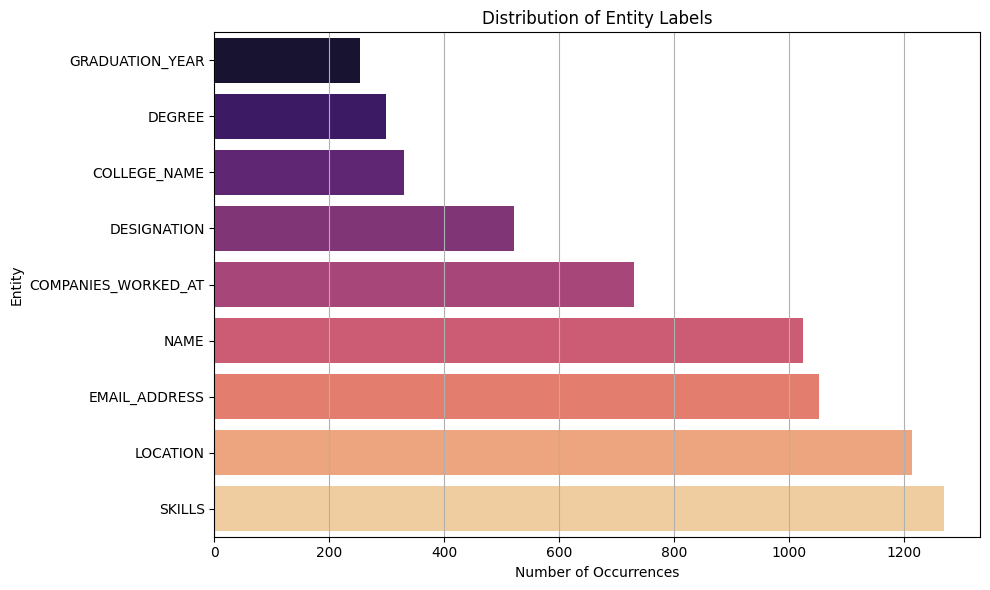

```python
entity_counts = Counter()
for anns in df_combined["clean_annotations"]:
    for ann in anns:
        entity = ann["label"].upper().replace(" ", "_")
        entity_counts[entity] += 1

entity_df = pd.DataFrame(entity_counts.items(), columns=["Entity", "Count"]).sort_values("Count", ascending=True)

plt.figure(figsize=(10, 6))
sns.barplot(x="Count", y="Entity", data=entity_df, palette="magma")
plt.title("Distribution of Entity Labels")
plt.xlabel("Number of Occurrences")
plt.ylabel("Entity")
plt.grid(True, axis="x")
plt.tight_layout()
plt.show()
```

#### 3. Job Tittles Cleaning

The next step focuses on cleaning and analyzing the job titles extracted from the resumes. Since raw titles often contain inconsistent formatting, abbreviations (like "Sr."), and irrelevant or noisy text, we define the clean_job_title function to standardize them. This includes expanding abbreviations, removing unwanted characters, and filtering out generic or uninformative titles like “intern” or “trainee.”

```python
def clean_job_title(raw_title):
    title = raw_title.lower().strip()

    replacements = {
        r"\bsr\.?\b": "senior",
        r"\bjr\.?\b": "junior",
        r"\bmgr\b": "manager",
        r"\bdev\b": "developer",
        r"\bassoc\.?\b": "associate",
        r"\bit\b": "it",
        r"\bqa\b": "quality assurance",
        r"\bdba\b": "database administrator"
    }
    for pattern, replacement in replacements.items():
        title = re.sub(pattern, replacement, title)

    noise_keywords = [
        "student", "intern", "trainee", "contestant", "fresher", "job",
        "training", "content analyst", "arabic language", "2001"
    ]
    if any(noise in title for noise in noise_keywords):
        return None

    title = re.sub(r"[^a-z\s]", "", title)
    title = re.sub(r"\s+", " ", title).strip()

    if len(title) < 3:
        return None

    return title
```

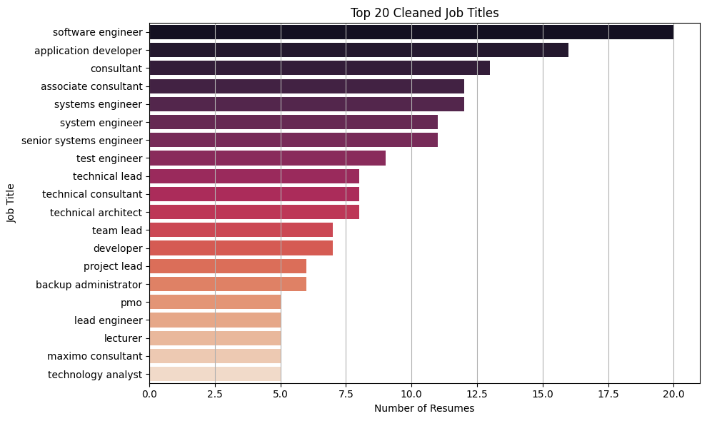

```python
job_titles = []
for anns in df_combined["clean_annotations"]:
    for ann in anns:
        if ann["label"].lower() == "designation":
            job_titles.append(ann["text"])

cleaned_titles = [clean_job_title(title) for title in job_titles]
cleaned_titles = [t for t in cleaned_titles if t]

title_counts = Counter(cleaned_titles)
job_df = pd.DataFrame(title_counts.items(), columns=["Job Title", "Count"]).sort_values("Count", ascending=False)

plt.figure(figsize=(10, 6))
sns.barplot(y="Job Title", x="Count", data=job_df.head(20), palette="rocket")
plt.title("Top 20 Cleaned Job Titles")
plt.xlabel("Number of Resumes")
plt.ylabel("Job Title")
plt.grid(True, axis='x')
plt.tight_layout()
plt.show()
```

## 3. 🔮 Predictions

In this chapter we are going to build our models, train and evaluate them.

### Preprocessing - BERT

To prepare the resume data for Named Entity Recognition (NER) model training, we first tokenize the text and align entity annotations to individual tokens. We use the BERT tokenizer (bert-base-cased) from Hugging Face Transformers to convert resume text into input IDs suitable for the model. Since annotations can vary in structure, we ensure they're consistently formatted using a helper function that flattens any nested annotation lists. We then extract all unique entity labels (e.g., EMAIL_ADDRESS, SKILLS, etc.) and apply the standard BIO tagging scheme (Begin, Inside, Outside) to capture multi-token entities effectively. Each token is assigned a corresponding label ID, with padding tokens ignored during training (-100).

To improve performance and avoid memory issues, the dataset is processed in batches, and once tokenized, it is saved to disk. In this step, we load that saved dataset using load_from_disk, allowing us to resume work efficiently without reprocessing. This results in a clean, structured dataset that can be directly fed into a transformer model for training.

```python
from transformers import AutoTokenizer
from datasets import Dataset

tokenizer = AutoTokenizer.from_pretrained("bert-base-cased")

def fix_nested_annotations(anns):
    if isinstance(anns, list) and len(anns) > 0 and isinstance(anns[0], list):
        anns = [item for sublist in anns for item in sublist]
    return anns

df_combined["clean_annotations"] = df_combined["clean_annotations"].apply(fix_nested_annotations)

unique_labels = sorted({
    ent["label"].upper().replace(" ", "_")
    for anns in df_combined["clean_annotations"]
    for ent in anns if isinstance(ent, dict) and ent.get("fixed", False)
})

label_list = ["O"] + [f"B-{l}" for l in unique_labels] + [f"I-{l}" for l in unique_labels]
label2id = {label: idx for idx, label in enumerate(label_list)}
id2label = {idx: label for label, idx in label2id.items()}
```

```python
def preprocess(batch):
    tokenized_batch = tokenizer(
        batch["content"],
        padding="max_length",
        truncation=True,
        max_length=512,
        return_offsets_mapping=True
    )

    all_labels = []

    for i in range(len(batch["content"])):
        labels = ["O"] * len(tokenized_batch["input_ids"][i])
        annotations = batch["clean_annotations"][i]

        for ent in annotations:
            if not isinstance(ent, dict) or not ent.get("fixed", False):
                continue
            ent_start, ent_end = ent["start"], ent["end"]
            ent_label = ent["label"].upper().replace(" ", "_")

            for j, (start, end) in enumerate(tokenized_batch["offset_mapping"][i]):
                if start is None or end is None or tokenized_batch["attention_mask"][i][j] == 0:
                    continue
                if start >= ent_start and end <= ent_end:
                    labels[j] = f"B-{ent_label}" if start == ent_start else f"I-{ent_label}"

        label_ids = [label2id.get(tag, 0) for tag in labels]
        label_ids = [
            label_id if tokenized_batch["attention_mask"][i][j] == 1 else -100
            for j, label_id in enumerate(label_ids)
        ]
        all_labels.append(label_ids)

    tokenized_batch["labels"] = all_labels
    tokenized_batch.pop("offset_mapping")
    return tokenized_batch
```

```python
# ran once as the memory becomes full
# hf_data = Dataset.from_pandas(df_combined[["content", "clean_annotations"]])

# tokenized_dataset = hf_data.map(
#     preprocess,
#     batched=True,
#     batch_size=8,
#     remove_columns=hf_data.column_names,
#     load_from_cache_file=False
# )

# tokenized_dataset = tokenized_dataset.train_test_split(test_size=0.2)

# tokenized_dataset.save_to_disk("tokenized_dataset")
```

```python
from datasets import load_from_disk

tokenized_dataset = load_from_disk("tokenized_dataset")
```

### Modelling - BERT

We load a pre-trained BERT model for token classification using bert-base-cased as the backbone. This model is specifically designed for sequence labeling tasks such as Named Entity Recognition (NER). By providing the num_labels, id2label, and label2id mappings, we customize the model for our resume-specific entity labels.

This step equips the model with the architecture needed to classify each token into one of our defined entity categories (e.g., B-NAME, I-SKILLS, etc.), while leveraging the contextual understanding BERT has already learned from general English corpora.

```python
import gc
import torch

# to help with memory
gc.collect()
torch.cuda.empty_cache()
```

```python
model = AutoModelForTokenClassification.from_pretrained(
    "bert-base-cased",
    num_labels=len(label_list),
    id2label=id2label,
    label2id=label2id
)
```

Next, we configure the training process with TrainingArguments, specifying:

Finally, we create a Trainer instance from Hugging Face's transformers library, passing the model, datasets, tokenizer, data collator, and metric function.

```python
data_collator = DataCollatorForTokenClassification(
    tokenizer=tokenizer,
    padding="max_length",
    max_length=512,
    return_tensors="pt"
)

def compute_metrics(pred):
    predictions, labels = pred
    predictions = predictions.argmax(axis=-1)

    true_labels, true_preds = [], []

    for p, l in zip(predictions, labels):
        current_true = []
        current_pred = []
        for pred_label, true_label in zip(p, l):
            if true_label != -100:
                current_true.append(id2label[true_label])
                current_pred.append(id2label[pred_label])
        true_labels.append(current_true)
        true_preds.append(current_pred)

    return classification_report(true_labels, true_preds, output_dict=True)

training_args = TrainingArguments(
    output_dir="./results",
    eval_strategy="epoch",
    save_strategy="epoch",
    per_device_train_batch_size=8,
    per_device_eval_batch_size=8,
    num_train_epochs=6,
    weight_decay=0.01,
    logging_dir="./logs",
    logging_steps=10
)

trainer = Trainer(
    model=model,
    args=training_args,
    train_dataset=tokenized_dataset["train"],
    eval_dataset=tokenized_dataset["test"],
    tokenizer=tokenizer,
    data_collator=data_collator,
    compute_metrics=compute_metrics
)
```

```python
trainer.train()

trainer.save_model("models/bert_ner")
```

### Evaluation - BERT

Now, we will evaluate the model. We have already a baseline established (the version of the notebook submitted in the Peer Reviews), where we trained the model only on 220 resumes with little to no Data Preparation.

```python
tokenizer = AutoTokenizer.from_pretrained("models/bert_ner")
model = AutoModelForTokenClassification.from_pretrained("models/bert_ner")
```

```python
eval_results = trainer.evaluate()
print(eval_results)
```

[output not shown]

```
{'eval_loss': 0.07434862107038498, 'eval_model_preparation_time': 0.002, 'eval_COLLEGE_NAME': {'precision': 0.6172839506172839, 'recall': 0.5617977528089888, 'f1-score': 0.588235294117647, 'support': 89}, 'eval_COMPANIES_WORKED_AT': {'precision': 0.907258064516129, 'recall': 0.9259259259259259, 'f1-…
```

We will be plotting now the training and validation loss over the 6 epochs. The training loss decreased sharply and stabilized below 0.05, indicating that the model learned effectively from the expanded dataset. Validation loss also dropped early and stabilized around 0.08, showing good generalization without significant overfitting. This is a strong indicator that the model is learning to extract entities accurately and consistently.

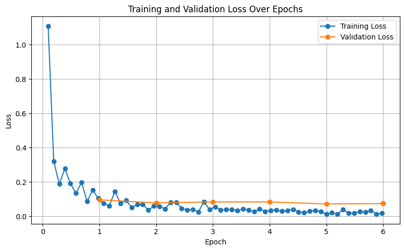

```python
log_history = pd.DataFrame(trainer.state.log_history)

train_loss = log_history[log_history["loss"].notna()][["epoch", "loss"]]
eval_loss = log_history[log_history["eval_loss"].notna()][["epoch", "eval_loss"]]

plt.figure(figsize=(8, 5))
plt.plot(train_loss["epoch"], train_loss["loss"], label="Training Loss", marker="o")
plt.plot(eval_loss["epoch"], eval_loss["eval_loss"], label="Validation Loss", marker="o")
plt.xlabel("Epoch")
plt.ylabel("Loss")
plt.title("Training and Validation Loss Over Epochs")
plt.legend()
plt.grid(True)
plt.tight_layout()
plt.show()
```

The evaluation results of the BERT model trained on 1000 resumes demonstrate a substantial improvement in performance compared to the earlier 220-resume model. Core entities such as NAME, EMAIL_ADDRESS, and LOCATION achieved exceptionally high F1-scores (up to 1.00 for NAME), indicating near-perfect recognition. More importantly, entities that previously performed poorly due to limited training examples—such as SKILLS, YEARS_OF_EXPERIENCE, and GRADUATION_YEA - now show significant gains, reaching F1-scores of 0.66, 0.71, and 0.72 respectively. Common resume fields like COMPANIES_WORKED_AT and DESIGNATION also perform robustly, with F1-scores above 0.90. Overall, the macro average F1-score improved from approximately 0.42 to 0.82, demonstrating that the model now handles both frequent and rare labels much more effectively. This confirms the value of expanding the dataset with synthetic and annotated resumes, making the model a much stronger candidate for real-world resume parsing tasks.

```python
predictions, labels, _ = trainer.predict(tokenized_dataset["test"])
pred_ids = predictions.argmax(axis=-1)

true_labels = []
true_preds = []

for pred, label in zip(pred_ids, labels):
    true_label = [id2label[l] for l in label if l != -100]
    pred_label = [id2label[p] for p, l in zip(pred, label) if l != -100]

    true_labels.append(true_label)
    true_preds.append(pred_label)

print(classification_report(true_labels, true_preds))
```

[output not shown]

```
<sklearn.metrics._plot.confusion_matrix.ConfusionMatrixDisplay at 0x22e14cbd0d0>
```

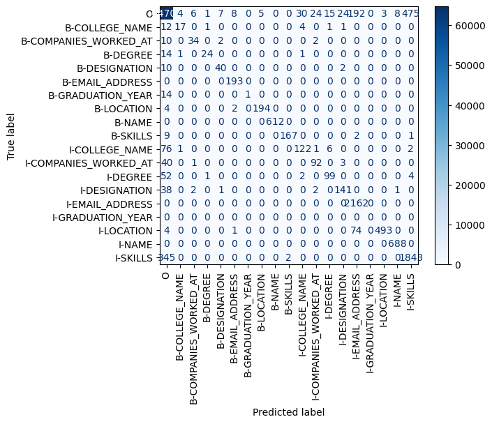

```python
flat_true = [l for row in true_labels for l in row]
flat_pred = [l for row in true_preds for l in row]

flat_true_ids = [label2id.get(l, 0) for l in flat_true]
flat_pred_ids = [label2id.get(l, 0) for l in flat_pred]

cm = confusion_matrix(flat_true_ids, flat_pred_ids, labels=list(label2id.values()))
disp = ConfusionMatrixDisplay(confusion_matrix=cm, display_labels=list(label2id.keys()))
disp.plot(xticks_rotation=90, cmap="Blues")
```

#### Comparison to 220-Resume Model

| **Metric** | **220 Resumes** | **1000 Resumes** |
| --- | --- | --- |
| Final training loss | ~0.16 | ~0.02 |
| Validation loss | ~0.29 | ~0.08 |
| Macro F1-score | ~0.42 | ~0.82 |
| Entity recognition | Only common labels (e.g. `NAME`, `EMAIL`) had good performance | More labels like `SKILLS`, `GRADUATION_YEAR`, `YEARS_OF_EXPERIENCE` improved |
| Overfitting signs | Minor overfitting, validation loss plateaued early | Minimal overfitting, stable training and evaluation loss curves |
| Training stability | Noisy loss curve with slow convergence | Smooth convergence and consistent evaluation across epochs |

Increasing the data to 1000 resumes led to better convergence, lower losses, and improved generalization. The model now performs better not only on frequent entities but also on rarer ones that were previously neglected due to data sparsity. The training curve shows no sign of overfitting, which means even more data could help, or the model could be made more complex (e.g. RoBERTa).

### Preprocessing - RoBERTa

After achieving strong results with BERT on 1000 resumes, we continue by training and evaluating a RoBERTa-based model to further explore performance improvements. RoBERTa is an optimized variant of BERT that removes the next sentence prediction objective and is trained with dynamic masking and more data, often resulting in better downstream performance. By applying RoBERTa to our named entity recognition task, we aim to assess whether its enhanced pretraining contributes to better generalization and entity extraction - especially on challenging fields like SKILLS or YEARS_OF_EXPERIENCE. The comparison with BERT will help us validate if RoBERTa provides measurable gains in both precision and consistency.

To prepare the data for training with RoBERTa, we tokenize each resume using the roberta-base tokenizer while preserving the character-to-token alignment through offset_mapping. This allows us to accurately project entity span annotations (like names or skills) from the raw text onto the tokenized representation. For each token, we initialize a sequence of labels using the BIO format (B-, I-, O) to represent the beginning and continuation of named entities. The corresponding label indices are then mapped using label2id, with padding tokens masked by assigning -100 to ignore them during loss computation. This ensures the model is trained only on relevant tokens. Due to memory limitations, the preprocessing and splitting were run once, saved to disk, and reloaded for model training.

```python
import gc
import torch

gc.collect()
torch.cuda.empty_cache()
```

```python
def compute_metrics(pred):
    predictions, labels = pred
    predictions = predictions.argmax(axis=-1)

    true_labels, true_preds = [], []

    for p, l in zip(predictions, labels):
        current_true = []
        current_pred = []
        for pred_label, true_label in zip(p, l):
            if true_label != -100:
                current_true.append(id2label[true_label])
                current_pred.append(id2label[pred_label])
        true_labels.append(current_true)
        true_preds.append(current_pred)

    return classification_report(true_labels, true_preds, output_dict=True)
```

```python
from transformers import AutoTokenizer

roberta_tokenizer = AutoTokenizer.from_pretrained("roberta-base")

def preprocess_roberta(example):
    tokenized = roberta_tokenizer(
        example["content"],
        padding="max_length",
        truncation=True,
        max_length=512,
        return_offsets_mapping=True
    )

    labels = ["O"] * len(tokenized["input_ids"])

    for ent in example["clean_annotations"]:
        if not ent.get("fixed", False):
            continue
        ent_start, ent_end = ent["start"], ent["end"]
        ent_label = ent["label"].upper().replace(" ", "_")

        for i, (start, end) in enumerate(tokenized["offset_mapping"]):
            if start is None or end is None:
                continue
            if start >= ent_start and end <= ent_end:
                labels[i] = f"B-{ent_label}" if start == ent_start else f"I-{ent_label}"

    label_ids = [label2id.get(tag, 0) for tag in labels]
    label_ids = [
        label_id if tokenized["attention_mask"][i] == 1 else -100
        for i, label_id in enumerate(label_ids)
    ]

    tokenized["labels"] = label_ids
    tokenized.pop("offset_mapping")
    return tokenized

# ran once because of memory issues
# hf_data_roberta = Dataset.from_pandas(df_combined[["content", "clean_annotations"]])
# tokenized_roberta = hf_data_roberta.map(preprocess_roberta, batched=False)
# tokenized_roberta = tokenized_roberta.train_test_split(test_size=0.2)
# tokenized_roberta.save_to_disk("tokenized_dataset_roberta")
```

```python
from datasets import load_from_disk

tokenized_roberta = load_from_disk("tokenized_dataset_roberta")
```

### Modeling - RoBERTa

For the modeling phase, we use distilroberta-base, a lighter and faster variant of RoBERTa that retains over 95% of its language understanding capabilities while reducing model size and training time. We load both the tokenizer and model using Hugging Face Transformers. The model is configured for token classification by specifying the number of unique labels in our dataset and providing mappings between label indices and their string representations (id2label and label2id). This setup enables the model to predict a class label for each token in a resume, supporting fine-grained entity extraction with efficient resource usage.

```python
from transformers import AutoTokenizer, AutoModelForTokenClassification

roberta_tokenizer = AutoTokenizer.from_pretrained("distilroberta-base")

roberta_model = AutoModelForTokenClassification.from_pretrained(
    "distilroberta-base",
    num_labels=len(label_list),
    id2label=id2label,
    label2id=label2id
)
```

```
Some weights of RobertaForTokenClassification were not initialized from the model checkpoint at distilroberta-base and are newly initialized: ['classifier.bias', 'classifier.weight']
You should probably TRAIN this model on a down-stream task to be able to use it for predictions and inference.
```

We configure the training pipeline for RoBERTa using Hugging Face's Trainer API. First, we define a DataCollatorForTokenClassification to handle padding and batching of input sequences during training. Then, we specify TrainingArguments, such as the number of epochs (6), batch sizes, evaluation and checkpointing strategies, logging frequency, and output directories. The Trainer is initialized with the model, tokenizer, datasets, and the metric function for evaluation. We then launch training with .train() and save the fine-tuned model to a local directory.

```python
from transformers import DataCollatorForTokenClassification, TrainingArguments, Trainer

roberta_data_collator = DataCollatorForTokenClassification(
    tokenizer=roberta_tokenizer,
    padding="max_length",
    max_length=512,
    return_tensors="pt"
)

roberta_training_args = TrainingArguments(
    output_dir="./results_roberta",
    eval_strategy="epoch",
    save_strategy="epoch",
    per_device_train_batch_size=8,
    per_device_eval_batch_size=8,
    num_train_epochs=6,
    weight_decay=0.01,
    logging_dir="./logs_roberta",
    logging_steps=10
)

roberta_trainer = Trainer(
    model=roberta_model,
    args=roberta_training_args,
    train_dataset=tokenized_roberta["train"],
    eval_dataset=tokenized_roberta["test"],
    tokenizer=roberta_tokenizer,
    data_collator=roberta_data_collator,
    compute_metrics=compute_metrics
)

roberta_trainer.train()

roberta_trainer.save_model("models/roberta_ner")
```

[612/612 55:54, Epoch 6/6]

| Epoch | Training Loss | Validation Loss | College Name | Companies Worked At | Degree | Designation | Email Address | Graduation Year | Location | Name | Phone Number | Skills | Unknown | Years Of Experience | Micro avg | Macro avg | Weighted avg |
| --- | --- | --- | --- | --- | --- | --- | --- | --- | --- | --- | --- | --- | --- | --- | --- | --- | --- |
| 1 | 0.117700 | 0.163414 | {'precision': 0.08620689655172414, 'recall': 0.0847457627118644, 'f1-score': 0.08547008547008547, 'support': 59} | {'precision': 0.8195121951219512, 'recall': 0.6885245901639344, 'f1-score': 0.7483296213808462, 'support': 244} | {'precision': 0.0, 'recall': 0.0, 'f1-score': 0.0, 'support': 24} | {'precision': 0.9408866995073891, 'recall': 0.7732793522267206, 'f1-score': 0.8488888888888889, 'support': 247} | {'precision': 0.9659367396593674, 'recall': 0.9851116625310173, 'f1-score': 0.9754299754299756, 'support': 403} | {'precision': 0.1651376146788991, 'recall': 0.44776119402985076, 'f1-score': 0.24128686327077747, 'support': 201} | {'precision': 0.9601990049751243, 'recall': 0.965, 'f1-score': 0.9625935162094762, 'support': 200} | {'precision': 0.9918300653594772, 'recall': 0.9967159277504105, 'f1-score': 0.9942669942669943, 'support': 609} | {'precision': 0.5705521472392638, 'recall': 0.48947368421052634, 'f1-score': 0.5269121813031162, 'support': 190} | {'precision': 0.34759358288770054, 'recall': 0.8783783783783784, 'f1-score': 0.49808429118773945, 'support': 74} | {'precision': 0.8, 'recall': 0.04597701149425287, 'f1-score': 0.08695652173913043, 'support': 87} | {'precision': 0.0, 'recall': 0.0, 'f1-score': 0.0, 'support': 92} | {'precision': 0.7, 'recall': 0.7460905349794239, 'f1-score': 0.7223107569721116, 'support': 2430} | {'precision': 0.5539879121650747, 'recall': 0.529580630291413, 'f1-score': 0.49735157826225257, 'support': 2430} | {'precision': 0.7653096740024333, 'recall': 0.7460905349794239, 'f1-score': 0.7331159382585215, 'support': 2430} |
| 2 | 0.086500 | 0.055333 | {'precision': 0.5769230769230769, 'recall': 0.5084745762711864, 'f1-score': 0.5405405405405405, 'support': 59} | {'precision': 0.9259259259259259, 'recall': 0.819672131147541, 'f1-score': 0.8695652173913043, 'support': 244} | {'precision': 0.9, 'recall': 0.375, 'f1-score': 0.5294117647058825, 'support': 24} | {'precision': 0.9356223175965666, 'recall': 0.8825910931174089, 'f1-score': 0.9083333333333334, 'support': 247} | {'precision': 0.980440097799511, 'recall': 0.9950372208436724, 'f1-score': 0.9876847290640394, 'support': 403} | {'precision': 0.37142857142857144, 'recall': 0.32338308457711445, 'f1-score': 0.3457446808510639, 'support': 201} | {'precision': 0.9698492462311558, 'recall': 0.965, 'f1-score': 0.9674185463659147, 'support': 200} | {'precision': 0.9950900163666121, 'recall': 0.9983579638752053, 'f1-score': 0.9967213114754099, 'support': 609} | {'precision': 0.9509803921568627, 'recall': 0.5105263157894737, 'f1-score': 0.6643835616438356, 'support': 190} | {'precision': 0.6288659793814433, 'recall': 0.8243243243243243, 'f1-score': 0.7134502923976608, 'support': 74} | {'precision': 0.7608695652173914, 'recall': 0.40229885057471265, 'f1-score': 0.5263157894736842, 'support': 87} | {'precision': 0.9090909090909091, 'recall': 0.7608695652173914, 'f1-score': 0.8284023668639053, 'support': 92} | {'precision': 0.8922317018410417, 'recall': 0.8176954732510288, 'f1-score': 0.853339059480352, 'support': 2430} | {'precision': 0.8254238415098354, 'recall': 0.6971279271448357, 'f1-score': 0.7398310111755478, 'support': 2430} | {'precision': 0.8886714585139469, 'recall': 0.8176954732510288, 'f1-score': 0.8436951954866951, 'support': 2430} |
| 3 | 0.070800 | 0.043780 | {'precision': 0.5945945945945946, 'recall': 0.3728813559322034, 'f1-score': 0.45833333333333337, 'support': 59} | {'precision': 0.9495412844036697, 'recall': 0.8483606557377049, 'f1-score': 0.8961038961038962, 'support': 244} | {'precision': 0.9333333333333333, 'recall': 0.5833333333333334, 'f1-score': 0.7179487179487181, 'support': 24} | {'precision': 0.9473684210526315, 'recall': 0.8744939271255061, 'f1-score': 0.9094736842105263, 'support': 247} | {'precision': 0.9828431372549019, 'recall': 0.9950372208436724, 'f1-score': 0.9889025893958076, 'support': 403} | {'precision': 0.719047619047619, 'recall': 0.7512437810945274, 'f1-score': 0.7347931873479319, 'support': 201} | {'precision': 0.9698492462311558, 'recall': 0.965, 'f1-score': 0.9674185463659147, 'support': 200} | {'precision': 0.9950900163666121, 'recall': 0.9983579638752053, 'f1-score': 0.9967213114754099, 'support': 609} | {'precision': 0.9808917197452229, 'recall': 0.8105263157894737, 'f1-score': 0.887608069164265, 'support': 190} | {'precision': 0.9444444444444444, 'recall': 0.4594594594594595, 'f1-score': 0.6181818181818182, 'support': 74} | {'precision': 0.8333333333333334, 'recall': 0.28735632183908044, 'f1-score': 0.4273504273504274, 'support': 87} | {'precision': 0.9333333333333333, 'recall': 0.7608695652173914, 'f1-score': 0.8383233532934132, 'support': 92} | {'precision': 0.9419964028776978, 'recall': 0.8621399176954733, 'f1-score': 0.9003008165019338, 'support': 2430} | {'precision': 0.8986392069284044, 'recall': 0.7255766583539631, 'f1-score': 0.7867632445142885, 'support': 2430} | {'precision': 0.9376082970117362, 'recall': 0.8621399176954733, 'f1-score': 0.8901095358276071, 'support': 2430} |
| 4 | 0.033500 | 0.045608 | {'precision': 0.6065573770491803, 'recall': 0.6271186440677966, 'f1-score': 0.6166666666666666, 'support': 59} | {'precision': 0.9330543933054394, 'recall': 0.9139344262295082, 'f1-score': 0.9233954451345756, 'support': 244} | {'precision': 0.8095238095238095, 'recall': 0.7083333333333334, 'f1-score': 0.7555555555555556, 'support': 24} | {'precision': 0.9333333333333333, 'recall': 0.9068825910931174, 'f1-score': 0.9199178644763861, 'support': 247} | {'precision': 0.9828009828009828, 'recall': 0.9925558312655087, 'f1-score': 0.9876543209876544, 'support': 403} | {'precision': 0.7894736842105263, 'recall': 0.8208955223880597, 'f1-score': 0.8048780487804879, 'support': 201} | {'precision': 0.9702970297029703, 'recall': 0.98, 'f1-score': 0.9751243781094527, 'support': 200} | {'precision': 0.9950900163666121, 'recall': 0.9983579638752053, 'f1-score': 0.9967213114754099, 'support': 609} | {'precision': 0.9719101123595506, 'recall': 0.9105263157894737, 'f1-score': 0.9402173913043478, 'support': 190} | {'precision': 0.6666666666666666, 'recall': 0.8648648648648649, 'f1-score': 0.7529411764705882, 'support': 74} | {'precision': 0.8307692307692308, 'recall': 0.6206896551724138, 'f1-score': 0.7105263157894737, 'support': 87} | {'precision': 0.7264150943396226, 'recall': 0.8369565217391305, 'f1-score': 0.7777777777777778, 'support': 92} | {'precision': 0.9190965092402464, 'recall': 0.9209876543209876, 'f1-score': 0.9200411099691677, 'support': 2430} | {'precision': 0.8513243108689936, 'recall': 0.8484263058182012, 'f1-score': 0.8467813543773649, 'support': 2430} | {'precision': 0.9223620003765938, 'recall': 0.9209876543209876, 'f1-score': 0.9204150196355464, 'support': 2430} |
| 5 | 0.016800 | 0.044605 | {'precision': 0.6307692307692307, 'recall': 0.6949152542372882, 'f1-score': 0.6612903225806452, 'support': 59} | {'precision': 0.9372384937238494, 'recall': 0.9180327868852459, 'f1-score': 0.9275362318840581, 'support': 244} | {'precision': 0.72, 'recall': 0.75, 'f1-score': 0.7346938775510204, 'support': 24} | {'precision': 0.9372384937238494, 'recall': 0.9068825910931174, 'f1-score': 0.9218106995884775, 'support': 247} | {'precision': 0.9828431372549019, 'recall': 0.9950372208436724, 'f1-score': 0.9889025893958076, 'support': 403} | {'precision': 0.8125, 'recall': 0.8407960199004975, 'f1-score': 0.8264058679706602, 'support': 201} | {'precision': 0.9702970297029703, 'recall': 0.98, 'f1-score': 0.9751243781094527, 'support': 200} | {'precision': 0.9950980392156863, 'recall': 1.0, 'f1-score': 0.9975429975429976, 'support': 609} | {'precision': 0.9719101123595506, 'recall': 0.9105263157894737, 'f1-score': 0.9402173913043478, 'support': 190} | {'precision': 0.518796992481203, 'recall': 0.9324324324324325, 'f1-score': 0.6666666666666667, 'support': 74} | {'precision': 0.828125, 'recall': 0.6091954022988506, 'f1-score': 0.7019867549668874, 'support': 87} | {'precision': 0.77, 'recall': 0.8369565217391305, 'f1-score': 0.8020833333333334, 'support': 92} | {'precision': 0.9114435907804286, 'recall': 0.9275720164609054, 'f1-score': 0.9194370793391801, 'support': 2430} | {'precision': 0.8395680441026033, 'recall': 0.8645645454349756, 'f1-score': 0.8453550925745296, 'support': 2430} | {'precision': 0.9218488292026302, 'recall': 0.9275720164609054, 'f1-score': 0.9220814409941075, 'support': 2430} |
| 6 | 0.012200 | 0.042776 | {'precision': 0.6029411764705882, 'recall': 0.6949152542372882, 'f1-score': 0.6456692913385826, 'support': 59} | {'precision': 0.9214876033057852, 'recall': 0.9139344262295082, 'f1-score': 0.9176954732510288, 'support': 244} | {'precision': 0.6923076923076923, 'recall': 0.75, 'f1-score': 0.7199999999999999, 'support': 24} | {'precision': 0.9416666666666667, 'recall': 0.9149797570850202, 'f1-score': 0.9281314168377823, 'support': 247} | {'precision': 0.9828431372549019, 'recall': 0.9950372208436724, 'f1-score': 0.9889025893958076, 'support': 403} | {'precision': 0.85, 'recall': 0.845771144278607, 'f1-score': 0.8478802992518704, 'support': 201} | {'precision': 0.9751243781094527, 'recall': 0.98, 'f1-score': 0.9775561097256857, 'support': 200} | {'precision': 0.9950980392156863, 'recall': 1.0, 'f1-score': 0.9975429975429976, 'support': 609} | {'precision': 0.9668508287292817, 'recall': 0.9210526315789473, 'f1-score': 0.9433962264150944, 'support': 190} | {'precision': 0.5144927536231884, 'recall': 0.9594594594594594, 'f1-score': 0.669811320754717, 'support': 74} | {'precision': 0.7638888888888888, 'recall': 0.632183908045977, 'f1-score': 0.6918238993710691, 'support': 87} | {'precision': 0.7938144329896907, 'recall': 0.8369565217391305, 'f1-score': 0.8148148148148148, 'support': 92} | {'precision': 0.9102615694164989, 'recall': 0.9308641975308642, 'f1-score': 0.9204476093591047, 'support': 2430} | {'precision': 0.8333762997968187, 'recall': 0.8703575269581343, 'f1-score': 0.8452687032249542, 'support': 2430} | {'precision': 0.9213425119808482, 'recall': 0.9308641975308642, 'f1-score': 0.923650287123079, 'support': 2430} |

[output not shown]

[output cut: 75 more lines]

### Evaluation - RoBERTa

```python
eval_results_roberta = roberta_trainer.evaluate()
print(eval_results_roberta)
```

[output not shown]

```
{'eval_loss': 0.042775820940732956, 'eval_COLLEGE_NAME': {'precision': 0.6029411764705882, 'recall': 0.6949152542372882, 'f1-score': 0.6456692913385826, 'support': 59}, 'eval_COMPANIES_WORKED_AT': {'precision': 0.9214876033057852, 'recall': 0.9139344262295082, 'f1-score': 0.9176954732510288, 'suppor…
```

```python
history_df_roberta = pd.DataFrame(roberta_trainer.state.log_history)

loss_df_roberta = history_df_roberta[history_df_roberta["loss"].notna() | history_df_roberta["eval_loss"].notna()]
print(loss_df_roberta[["epoch", "loss", "eval_loss"]])
```

```
       epoch    loss  eval_loss
0   0.098039  0.2997        NaN
1   0.196078  0.2689        NaN
2   0.294118  0.2211        NaN
3   0.392157  0.1871        NaN
4   0.490196  0.1484        NaN
..       ...     ...        ...
63  5.784314  0.0298        NaN
64  5.882353  0.0344        NaN
65  5.980392  0.0122        NaN
66  6.000000     NaN   0.042776
68  6.000000     NaN   0.042776

[68 rows x 3 columns]
```

Now, we plot again the training and validation loss over epochs. Training loss decreases rapidly during the first two epochs and continues to drop steadily across all six epochs, eventually stabilizing around 0.02. Validation loss follows a similar pattern, converging around 0.04 and remaining stable thereafter, with no indication of overfitting. This suggests that the model is learning effectively and generalizing well to unseen data. Compared to the BERT model, RoBERTa achieves comparable, if not slightly better, training dynamics—especially in terms of convergence speed and final loss levels. The consistent gap between training and validation loss also indicates that regularization and hyperparameter settings are well-balanced.

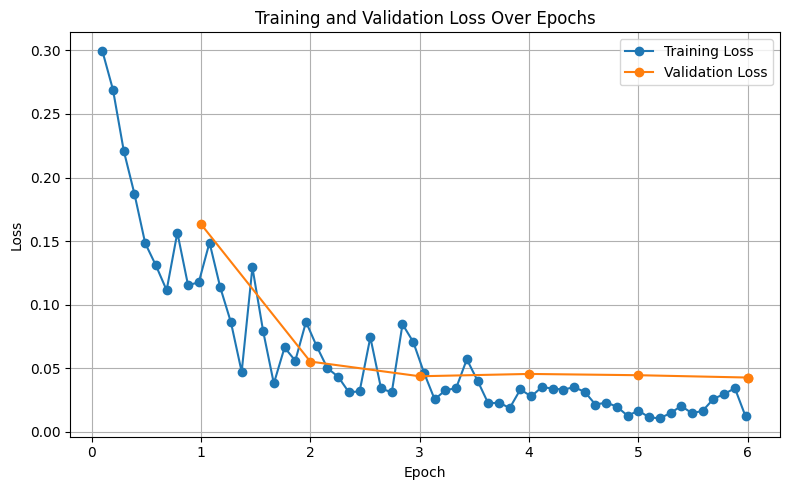

```python
log_history_roberta = pd.DataFrame(roberta_trainer.state.log_history)

train_loss_roberta = log_history_roberta[log_history_roberta["loss"].notna()][["epoch", "loss"]]
eval_loss_roberta = log_history_roberta[log_history_roberta["eval_loss"].notna()][["epoch", "eval_loss"]]

plt.figure(figsize=(8, 5))
plt.plot(train_loss_roberta["epoch"], train_loss_roberta["loss"], label="Training Loss", marker="o")
plt.plot(eval_loss_roberta["epoch"], eval_loss_roberta["eval_loss"], label="Validation Loss", marker="o")
plt.xlabel("Epoch")
plt.ylabel("Loss")
plt.title("Training and Validation Loss Over Epochs")
plt.legend()
plt.grid(True)
plt.tight_layout()
plt.show()
```

```python
predictions, labels, _ = roberta_trainer.predict(tokenized_roberta["test"])
pred_ids = predictions.argmax(axis=-1)

true_labels = []
true_preds = []

for pred, label in zip(pred_ids, labels):
    true_label = [id2label[l] for l in label if l != -100]
    pred_label = [id2label[p] for p, l in zip(pred, label) if l != -100]

    true_labels.append(true_label)
    true_preds.append(pred_label)

print(classification_report(true_labels, true_preds))
```

```
                     precision    recall  f1-score   support

       COLLEGE_NAME       0.60      0.69      0.65        59
COMPANIES_WORKED_AT       0.92      0.91      0.92       244
             DEGREE       0.69      0.75      0.72        24
        DESIGNATION       0.94      0.91      0.93       247
      EMAIL_ADDRESS       0.98      1.00      0.99       403
    GRADUATION_YEAR       0.85      0.85      0.85       201
           LOCATION       0.98      0.98      0.98       200
               NAME       1.00      1.00      1.00       609
       PHONE_NUMBER       0.97      0.92      0.94       190
             SKILLS       0.51      0.96      0.67        74
            UNKNOWN       0.76      0.63      0.69        87
YEARS_OF_EXPERIENCE       0.79      0.84      0.81        92

          micro avg       0.91      0.93      0.92      2430
          macro avg       0.83      0.87      0.85      2430
       weighted avg       0.92      0.93      0.92      2430
```

```
<sklearn.metrics._plot.confusion_matrix.ConfusionMatrixDisplay at 0x1b61b92c450>
```

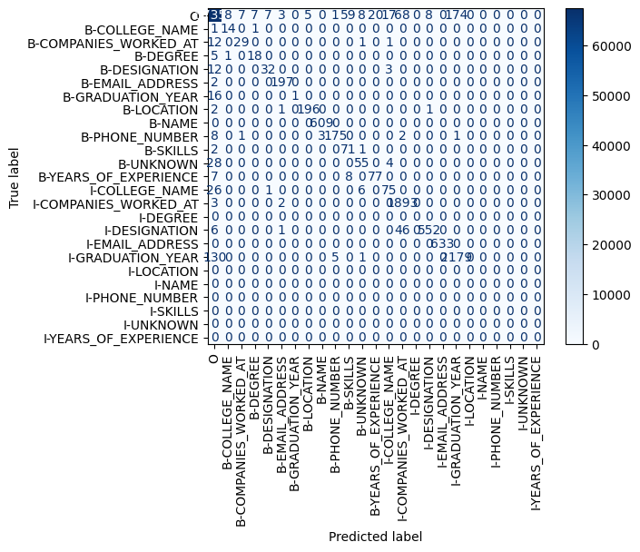

```python
flat_true = [l for row in true_labels for l in row]
flat_pred = [l for row in true_preds for l in row]

flat_true_ids = [label2id.get(l, 0) for l in flat_true]
flat_pred_ids = [label2id.get(l, 0) for l in flat_pred]

cm = confusion_matrix(flat_true_ids, flat_pred_ids, labels=list(label2id.values()))
disp = ConfusionMatrixDisplay(confusion_matrix=cm, display_labels=list(label2id.keys()))
disp.plot(xticks_rotation=90, cmap="Blues")
```

### Comparison BERT vs RoBERTa

### BERT vs. RoBERTa (1000 Resumes)

| **Metric** | **BERT** | **RoBERTa** |
| --- | --- | --- |
| Final training loss | ~0.02 | ~0.01 |
| Final validation loss | ~0.08 | ~0.04 |
| Macro F1-score | 0.82 | 0.85 |
| Weighted F1-score | 0.88 | 0.92 |
| Entity recognition | Strong on common + rare entities | Better recall, especially on `SKILLS`, `YEARS_OF_EXPERIENCE` |
| SKILLS F1-score | 0.66 | 0.67 (w/ recall: 0.96) |
| Overall performance | High accuracy | Slightly better generalization and balance |

## 4. 📈 Resume Scoring Engine

In this section, we implement a Resume Scoring Engine that evaluates how well a candidate’s resume aligns with a specific job description. The final product is a web application where users can upload their resume and a description of a job posting, and receive structured insights in return. Our trained BERT or RoBERTa models extract key information from the resume in JSON format—such as skills, education, experience, etc.—and then a scoring function is used to assess how well the candidate fits the job. Afterwards, as an addition a feedback generated by an LLM is provided.

### Initial Scoring Engine

This is the first version of the scoring engine with test data and a simple scoring algorithm where the CV is matched against the job discription and a score is provided.

```python
# example json output from the BERT and RoBERTa
resume = {
    "skills": ["python", "nlp", "azure", "docker"],
    "degree": "MSc Computer Science",
    "years_of_experience": 3,
    "education_level": "bachelor"
}
```

```python
# expample job posting that will be retrieved from the web app
job_posting = {
    "required_skills": ["python", "nlp", "mlflow", "azure"],
    "min_experience": 5,
    "preferred_degree": "bachelor"
}
```

```python
def score_resume(resume, job_posting):
    score = 0
    max_score = 100

    resume_skills = set(resume.get("skills", []))
    required_skills = set(job_posting.get("required_skills", []))
    matched_skills = resume_skills & required_skills
    skill_coverage = len(matched_skills) / len(required_skills) if required_skills else 0
    score += skill_coverage * 40

    extra_keywords = resume_skills - required_skills
    richness_ratio = len(extra_keywords) / 10
    score += min(richness_ratio, 1.0) * 20

    degree = resume.get("education_level", "").lower()
    required = job_posting.get("preferred_degree", "").lower()
    if degree == required:
        score += 20
    elif degree in ["master", "phd"] and required == "bachelor":
        score += 15
    elif degree == "bachelor" and required in ["master", "phd"]:
        score += 10
    else:
        score += 0

    years = resume.get("years_of_experience", 0)
    required_years = job_posting.get("min_experience", 0)
    if years >= required_years:
        score += 20
    else:
        score += max(0, (years / required_years) * 20)

    return round(score, 2)
```

```python
result = score_resume(resume, job_posting)
print(f"📊 Resume Score: {result}/100")
```

[output not shown]

### Advanced and Final Scoring Engine

Now, we continue with a more advanced scoring engine that is going to be actually used in the web app.

In the next code, we define score_resume_advanced_explained, a function that calculates a matching score between a candidate’s resume and a job posting, while also building a detailed explanation of how the score was computed. The function evaluates the resume on several key dimensions: skill coverage, preferred technologies, seniority level, education, and experience. Each of these contributes points toward a final score (capped at 100).

For each category, an explanation string is created that clearly shows how many points were awarded and why. This detailed feedback not only supports transparency but also helps users understand how their resume aligns with the job requirements.

```python
def score_resume_advanced_explained(resume, job_posting):
    score = 0
    explanation = {}

    def normalize_skill(s):
        return s.strip().lower()

    resume_skills = set(map(normalize_skill, resume.get("skills", [])))
    required_skills = set(map(normalize_skill, job_posting.get("required_skills", [])))
    preferred_tech = set(map(normalize_skill, job_posting.get("preferred_tech", [])))

    matched_skills = {r for r in required_skills for s in resume_skills if r in s or s in r}
    skill_coverage = len(matched_skills) / len(required_skills) if required_skills else 0
    skill_points = skill_coverage * 40
    score += skill_points
    explanation["Skill coverage"] = f"{len(matched_skills)}/{len(required_skills)} matched → +{round(skill_points,2)} points"

    tech_match = {p for p in preferred_tech for s in resume_skills if p in s or s in p}
    tech_coverage = len(tech_match) / len(preferred_tech) if preferred_tech else 0
    tech_points = tech_coverage * 10
    score += tech_points
    explanation["Preferred tech"] = f"{len(tech_match)}/{len(preferred_tech)} matched → +{round(tech_points,2)} points"

    resume_title = resume.get("designation", "").lower()
    summary = resume.get("summary", "").lower()
    seniority = job_posting.get("seniority_level", "").lower()
    seniority_points = 0
    if seniority in resume_title or seniority in summary:
        seniority_points = 10
    elif resume.get("years_of_experience", 0) >= job_posting.get("min_experience", 0) and seniority in ["senior", "lead"]:
        seniority_points = 5
    score += seniority_points
    explanation["Seniority level"] = f"Matched seniority: +{seniority_points} points"

    degree = resume.get("education_level", "").lower()
    required_degree = job_posting.get("preferred_degree", "").lower()
    edu_points = 0
    if "bachelor" in degree and "bachelor" in required_degree:
        edu_points = 20
    elif "master" in degree and required_degree == "bachelor":
        edu_points = 15
    elif "phd" in degree and required_degree == "bachelor":
        edu_points = 15
    elif "bachelor" in degree and required_degree in ["master", "phd"]:
        edu_points = 10
    elif degree == required_degree:
        edu_points = 20
    score += edu_points
    explanation["Education"] = f"{degree.title()} vs {required_degree.title()} → +{edu_points} points"

    years = resume.get("years_of_experience", 0)
    min_years = job_posting.get("min_experience", 0)
    exp_points = 0
    if years >= min_years:
        exp_points = 20
        exp_points += min(5, (years - min_years))
    else:
        exp_points = (years / min_years) * 20 if min_years else 0
    score += exp_points
    explanation["Experience"] = f"{years}/{min_years} years → +{round(exp_points,2)} points"

    final_score = round(min(score, 100), 2)
    return final_score, explanation
```

To improve the engine even more, we are going to use an LLM. We define the generate_resume_feedback function, which uses OpenAI’s GPT model (gpt-3.5-turbo) to provide personalized feedback on how a resume matches a given job description. The function constructs a detailed prompt that includes the extracted resume information (skills, designation, education, and experience) and the job posting details (required skills, preferred technologies, seniority level, degree, and minimum experience).

By sending this prompt to the language model, we ask it to compare the two and generate constructive feedback. Specifically, the AI highlights which skills are missing, which should be emphasized, and how the resume can be better tailored for the job. The result is a natural-language response that helps candidates understand how to strengthen their resume for a particular role.

```python
client = openai.OpenAI(api_key="secret")

def generate_resume_feedback(resume, job_posting):
    resume_text = f"""
    Resume Extracted:
    Skills: {', '.join(resume.get('skills', []))}
    Designation: {resume.get('designation', '')}
    Education: {resume.get('education_level', '')}
    Years of Experience: {resume.get('years_of_experience', '')}
    """

    job_text = f"""
    Job Description:
    Required Skills: {', '.join(job_posting.get('required_skills', []))}
    Preferred Tech: {', '.join(job_posting.get('preferred_tech', []))}
    Seniority Level: {job_posting.get('seniority_level', '')}
    Preferred Degree: {job_posting.get('preferred_degree', '')}
    Min Experience: {job_posting.get('min_experience', '')}
    """

    prompt = f"""
    Compare the following resume to the job description and provide feedback:
    - What skills are missing?
    - Which skills should be emphasized?
    - How could the resume be tailored better for this job?

    {resume_text}
    {job_text}
    """

    response = client.chat.completions.create(
        model="gpt-3.5-turbo",
        messages=[
            {"role": "system", "content": "You are an expert career coach."},
            {"role": "user", "content": prompt}
        ],
        temperature=0.7
    )

    return response.choices[0].message.content.strip()
```

In the next part, we load our fine-tuned RoBERTa model and tokenizer to extract key information from a resume text. The model performs Named Entity Recognition (NER) to identify entities like skills, degree, designation, and years of experience from the resume. After tokenizing the input resume, we run the model to predict entity labels for each token. We then iterate over the tokens and their predicted labels, reconstructing full entity texts where appropriate.

To improve robustness, we add a regex fallback: if certain entities (e.g., skills, degree, or experience) are missing from the model output, we use regular expressions to try to extract these details directly from the raw text. This hybrid approach ensures better coverage and reliability, even if the model fails to recognize some entities.

The final result is a structured dictionary, resume_extracted, which contains the extracted skills, degree, designation, and years of experience.

```python
tokenizer = AutoTokenizer.from_pretrained("models/roberta_ner")
model = AutoModelForTokenClassification.from_pretrained("models/roberta_ner")
id2label = model.config.id2label

trainer = Trainer(model=model, tokenizer=tokenizer)

test_resume_text = {
    "content": """Name: Emily Johnson
Email: emily.johnson@example.com
Phone: +1-555-987-6543
Location: Austin, TX

Summary:
Results-driven Front-End Developer with 4 years of experience building responsive and user-friendly web applications. Skilled in modern frameworks and passionate about improving the user experience through clean and efficient code.

Skills:
- Programming Languages: JavaScript, TypeScript, HTML, CSS
- Frameworks: React, Angular
- Version Control: Git
- Testing: Jest, Cypress
- Agile methodologies
- Responsive design

Education:
Bachelor of Science in Information Technology
University of Texas at Austin
Graduated: May 2018

Work Experience:
Front-End Developer
Creative Web Solutions, Austin, TX
June 2018 - Present
- Developed interactive web applications using React and Angular
- Collaborated with UX/UI teams to enhance design usability
- Ensured cross-browser compatibility and responsive design
- Wrote unit and integration tests using Jest and Cypress

Feel free to contact me for further information or collaboration opportunities.
"""
}

job_posting = {
    "required_skills": ["javascript", "react", "html", "css", "git"],
    "preferred_tech": ["angular", "cypress", "responsive design"],
    "seniority_level": "front-end developer",
    "preferred_degree": "bachelor",
    "min_experience": 3
}


inputs = tokenizer(
    test_resume_text["content"],
    return_tensors="pt",
    truncation=True,
    padding="max_length",
    max_length=512
)

outputs = model(**inputs)
predictions = outputs.logits.argmax(dim=-1)[0].tolist()
tokens = tokenizer.convert_ids_to_tokens(inputs["input_ids"][0])
labels = [id2label[p] for p in predictions]

resume_extracted = {
    "skills": [],
    "designation": "",
    "education_level": "",
    "years_of_experience": 0
}

current_entity = None
current_text = ""

for token, label in zip(tokens, labels):
    clean_token = token.replace("Ġ", "").replace("▁", "")

    if label == "O":
        if current_entity:
            if current_entity == "SKILLS":
                resume_extracted["skills"].append(current_text.strip())
            elif current_entity == "DEGREE":
                resume_extracted["education_level"] = current_text.strip()
            elif current_entity == "DESIGNATION":
                resume_extracted["designation"] = current_text.strip()
            elif current_entity == "YEARS_OF_EXPERIENCE":
                try:
                    resume_extracted["years_of_experience"] = int(current_text.strip())
                except:
                    pass
            current_entity = None
            current_text = ""
    else:
        label_clean = label.split("-", 1)[-1]
        if current_entity == label_clean:
            current_text += " " + clean_token
        else:
            if current_entity:
                if current_entity == "SKILLS":
                    resume_extracted["skills"].append(current_text.strip())
                elif current_entity == "DEGREE":
                    resume_extracted["education_level"] = current_text.strip()
                elif current_entity == "DESIGNATION":
                    resume_extracted["designation"] = current_text.strip()
                elif current_entity == "YEARS_OF_EXPERIENCE":
                    try:
                        resume_extracted["years_of_experience"] = int(current_text.strip())
                    except:
                        pass
            current_entity = label_clean
            current_text = clean_token

resume_extracted["skills"] = [s for s in resume_extracted["skills"] if s.strip()]
resume_extracted["designation"] = resume_extracted["designation"].strip()

content = test_resume_text["content"]

if not resume_extracted["skills"]:
    skills_match = re.search(r"Skills:\s*(.*?)(Education|Work Experience|$)", content, re.S | re.I)
    if skills_match:
        skills_section = skills_match.group(1)
        skills_list = re.findall(r"-\s*(.+)", skills_section)
        resume_extracted["skills"] = [s.strip() for s in skills_list]

if not resume_extracted["education_level"]:
    edu_match = re.search(r"Bachelor.*|Master.*|MSc.*|PhD.*", content, re.I)
    if edu_match:
        resume_extracted["education_level"] = edu_match.group().strip()

if resume_extracted["years_of_experience"] == 0:
    exp_match = re.search(r"(\d+)\s+years", content, re.I)
    if exp_match:
        resume_extracted["years_of_experience"] = int(exp_match.group(1))

print("\n📋 Extracted Resume Data (Hybrid):")
print(resume_extracted)
```

```
📋 Extracted Resume Data (Hybrid):
{'skills': ['Programming Languages: JavaScript, TypeScript, HTML, CSS', 'Frameworks: React, Angular', 'Version Control: Git', 'Testing: Jest, Cypress', 'Agile methodologies', 'Responsive design'], 'designation': ', TX', 'education_level': 'Bachelor of Science in Information Technology', 'years_of_ex…
```

```python
final_score, breakdown = score_resume_advanced_explained(resume_extracted, job_posting)

print(f"\n📊 Final Score: {final_score}/100")
print("💡 Breakdown:")
for key, val in breakdown.items():
    print(f"- {key}: {val}")
```

```
📊 Final Score: 91.0/100
💡 Breakdown:
- Skill coverage: 5/5 matched → +40.0 points
- Preferred tech: 3/3 matched → +10.0 points
- Seniority level: Matched seniority: +0 points
- Education: Bachelor Of Science In Information Technology vs Bachelor → +20 points
- Experience: 4/3 years → +21 points
```

```python
generate_resume_feedback(resume_extracted, job_posting)
```

```
"Based on the job description provided, here is the feedback on the resume extract:\n\nMissing Skills:\n1. The resume is missing specific experience with Git, which is listed as a required skill in the job description.\n2. The resume does not mention experience with HTML and CSS, both of which are r…
```

## 5. 🚀 Conclusion

At this stage of the project, we have successfully developed a robust and intelligent resume analysis system. Our journey began with data provisioning, where we generated ~800 high-quality synthetic resumes using OpenAI and combined them with a smaller annotated dataset from Kaggle. We implemented automatic annotation logic, followed by thorough cleaning and standardization to ensure data consistency.

We then built and trained two Named Entity Recognition (NER) models — BERT and RoBERTa — using HuggingFace Transformers. Our BERT model, trained on the expanded dataset of 1000 resumes, demonstrated significant improvements in macro F1-score over the initial 220-resume version. RoBERTa further complemented this with competitive performance, showing particular strength in extracting entities like SKILLS, GRADUATION_YEAR, and YEARS_OF_EXPERIENCE.

Building on these models, we designed an enhanced Resume Scoring Engine that evaluates resumes across multiple dimensions: skill match, preferred technologies, seniority level alignment, education fit, and years of experience. This engine not only generates a score normalized to a 100-point scale but also provides a detailed breakdown that transparently explains how the score was derived.

To enrich the user experience, we integrated a Large Language Model (LLM) (OpenAI’s GPT) to generate tailored, natural-language feedback. This feedback highlights missing or underemphasized skills, recommends improvements, and guides users on how to align their resumes more closely with a given job posting.

Finally, we wrapped this system in a user-friendly Streamlit web app, allowing users to upload or paste their resumes, enter job details, and instantly receive both structured resume extractions, a comprehensive fit score, and actionable AI-generated recommendations. The Streamlit app incorporates the logic provided in this notebook and can be found in the same zip file as this notebook.

Future Recommendations:

- Continuously evaluate and fine-tune the NER models with additional real-world data to improve extraction accuracy.